# How does migration background affect COVID-19 vaccination intentions? A complex relationship between general attitudes, religiosity, acculturation and fears of infection.

Online Appendix

2021-12-21

# Operationalization

The following gives an overview of the variables used in the article.

### Vaccination intention

**Instructions**

*None*

**Items**

| Abbr. | Wording |
| --- | --- |
| `vaxx` | How would you decide, if next week you had the possibility to get vaccinated against COVID-19? |
|  | [Wie würden Sie entscheiden, wenn Sie nächste Woche die Möglichkeit hätten, sich gegen COVID−19 impfen zu lassen?] |

**Responses**

The response scale for the item was a seven-point rating scale with end points labelled: 1 “would not vaccinate at all” and 7 “would vaccinate definetly” [1 “auf keinen Fall impfen” and 7 “auf jeden Fall impfen”].

### Fear of Coronavirus

**Instructions**

Please tell us to what extent the following statements concerning the Coronavirus apply to you.

[Bitte geben Sie an, wie sehr die folgenden Aussagen in Bezug auf das Coronavirus zutreffen.]

**Items**

| Abbr. | Wording |
| --- | --- |
| `fear_infect` | I am afraid of getting infected by the Coronavirus. |
|  | [Ich fürchte mich davor, mit Corona infiziert zu werden.] |
| `fear_contr` | I am afraid of infecting my family and friends with the virus. |
|  | [Ich fürchte mich davor, Angehörige und Freunde mit dem Virus anzustecken.] |

**Responses**

The response scale for each item was a seven-point rating scale with end points labelled: 1 “do not agree at all” und 7 “agree fully”.

### Health consciousness

**Instructions**

To what extent do you agree with the following statements?

[Inwiefern stimmen Sie den folgenden Aussagen zu?]

**Items**

| Abbr. | Wording |
| --- | --- |
| `h_worry` | I am worried about my health. |
|  | [Ich mache mir Sorgen um die eigene Gesundheit.] |
| `h_imp` | I am very shocked when there are reports about serious diseases in the media. |
|  | [Wenn in den Medien über schwere Krankheiten berichtet wird, bin ich immer ganz erschüttert.] |
| `media_di` | There is nothing more important in life than thinking about your health . |
|  | [Es gibt im Leben gar nichts Wichtigeres, als an die Gesundheit zu denken.] |

**Responses**

The response scale for each item was a seven-point rating scale with end points labelled: 1 “do not agree at all” und 7 “agree fully”.

**Notes**

All three items are used as indicators of the latent factor health consciousness (`h_cons`)

### Political Trust

**Instructions**

I am going to name a variety of public institutions and organisations. Please tell me about every institution or organisation the degree of trust you have towards it. To what degree do you trust…

[Ich nenne Ihnen jetzt eine Reihe von öffentlichen Einrichtungen und Organisationen. Sagen Sie mir bitte bei jeder Einrichtung oder Organisation, wie groß das Vertrauen ist, das Sie ihr entgegenbringen. Wie hoch ist ihr Vertrauen gegenüber…]

**Items**

| Abbr. | Wording |
| --- | --- |
| `otrust_gov` | the federal government |
|  | [der Bundesregierung] |
| `otrust_hth` | the health agency |
|  | [dem Gesundheitsamt] |
| `otrust_med` | the media |
|  | [den Medien] |
| `otrust_pol` | the police |
|  | [der Polizei] |
| `otrust_parl` | the parliament |
|  | [dem Bundestag] |

**Responses**

The response scale for each item was a seven-point rating scale with end points labelled: 1 “no trust at all” und 7 “a lot of trust”. [1 “überhaupt kein Vertrauen” and 7 “sehr großes Vertrauen”].

**Notes**

Four of the five items are used as indicators of the latent factor political trust (`pol_trust`)

### Religiosity

**Instructions**

*None*

**Items**

[output not shown]

**Responses**

The response scale for the item was a seven-point rating scale with end points labelled: 1 “not religious at all” and 7 “very religious” [1 “gar nicht religiös” and 7 “sehr religiös”].

### Media consumption

**Instructions**

Now, lets talk about your life in Germany. To what degree apply the following statements? [Nun geht es um Ihr Leben in Deutschland. Inwiefern treffen folgende Aussagen für Sie zu?]

**Items**

| Abbr. | Wording |
| --- | --- |
| `media_cor` | I use media from my/ my parents’ country of origin (tv, radio, newspaper, magazines etc.) |
|  | [Ich benutze Medien aus meinem Herkunftsland bzw. aus dem Herkunftsland meiner Eltern (TV, Radio, Zeitung, Zeitschriften etc.)] |
| `media_ger` | I use German media (tv, radio, newspaper, magazines etc.) |
|  | [Ich benutze deutsche Medien (TV, Radio, Zeitung, Zeitschriften etc.)] |

**Responses**

The response scale for each item was a seven-point rating scale with end points labelled: 1 “does not apply at all” und 7 “applies fully” [1 “trifft überhaupt nicht zu” and 7 “trifft voll und ganz zu”].

### Years Since Migration

**Instructions**

Since when do you live in Germany (also former GDR) If you came from another country than Germany, please state when you moved to Germany for the first time, even if you lived somewhere else. [Seit wann leben Sie in Deutschland (auch DDR)? Wenn Sie aus einem anderen Land als Deutschland herkommen, bitte geben Sie an wann Sie das erste Mal nach Deutschland gezogen sind, auch wenn Sie mal woanders gelebt haben.]

**Items**

| Abbr. | Wording |
| --- | --- |
| `ysm` | Since… |
|  | [Seit…] |

**Responses**

The response scale for the item was a dropdown selection ranging from “before 1950” to “2020”

**Notes**

This item was recoded to get a numeric variable that counts the years since migration until 2021.

### Demographic Covariates

**Items**

| Abbr. | Variable |
| --- | --- |
| `educ` | Educational Attainment [1=upper secondary and higher, 0=lower secondary and lower] |
| `sex` | Gender [1=male, 0=female] |
| `age` | Age [in years] |
| `inc` | Personal net monthly income [1=less than 500, 9=more than 4000] |

**Notes**

The “still going to school” category was recoded as missing value. The third “diverse” category for gender only yielded n=3 respondents, who were then recoded as missing values. Age was computed from the birth year question by subtracting birth year from the survey year 2021. Birth year was inquired in the survey via dropdown selection.

# Models

The following contains the full code and summary outputs of the models featured in the article.

## Setup

Two datasets are created, the all respondents dataset (n=1027) and the migrants only dataset (n=389)

## Measurement model, all respondents

Measurement model of latent factors health consciousness and political trust for all respondents (n=1027)

*Click ‘Code’ to see syntax*

```r
model01 <- '
  # Identify latent factors
  #identify latent factors
  h_cons =~ h_worry  + media_di + h_imp
  pol_trust =~ otrust_gov + otrust_hth + otrust_med + otrust_pol #+ otrust_parl

  #error correlations
  otrust_med ~~ otrust_pol
  otrust_gov ~~ otrust_hth

'
fit_m01 <- sem(model01, df1, meanstructure = TRUE, missing = "fiml")
df1_pr <- as.data.frame(lavPredict(fit_m01, newdata=df1, type= "lv", method="ML", label=T, append.data = T))
```

**Click here for output**

```r
summary(fit_m01, standardized = TRUE, fit.measures = TRUE, rsquare = TRUE)
```

```
## lavaan 0.6-9 ended normally after 56 iterations
##
##   Estimator                                         ML
##   Optimization method                           NLMINB
##   Number of model parameters                        24
##
##   Number of observations                          1027
##   Number of missing patterns                        10
##
## Model Test User Model:
##
##   Test statistic                                38.082
##   Degrees of freedom                                11
##   P-value (Chi-square)                           0.000
##
## Model Test Baseline Model:
##
##   Test statistic                              2330.696
##   Degrees of freedom                                21
##   P-value                                        0.000
##
## User Model versus Baseline Model:
##
##   Comparative Fit Index (CFI)                    0.988
##   Tucker-Lewis Index (TLI)                       0.978
##
## Loglikelihood and Information Criteria:
##
##   Loglikelihood user model (H0)             -12495.979
##   Loglikelihood unrestricted model (H1)     -12476.938
##
##   Akaike (AIC)                               25039.958
##   Bayesian (BIC)                             25158.384
##   Sample-size adjusted Bayesian (BIC)        25082.157
##
## Root Mean Square Error of Approximation:
##
##   RMSEA                                          0.049
##   90 Percent confidence interval - lower         0.033
##   90 Percent confidence interval - upper         0.066
```

[output cut: 51 more lines]

```
##    .otrust_hth        1.362    0.210    6.476    0.000    1.362    0.465
##    .otrust_med        1.174    0.195    6.010    0.000    1.174    0.458
##    .otrust_pol        0.472    0.261    1.806    0.071    0.472    0.191
##     h_cons            1.028    0.122    8.392    0.000    1.000    1.000
##     pol_trust         0.922    0.151    6.092    0.000    1.000    1.000
##
## R-Square:
##                    Estimate
##     h_worry           0.395
##     media_di          0.477
##     h_imp             0.339
##     otrust_gov        0.365
##     otrust_hth        0.535
##     otrust_med        0.542
##     otrust_pol        0.809
```

**Click here for mod.indices**

```r
modindices(fit_m01,minimum.value = 3.9, sort.=T)
```

```
##          lhs op        rhs     mi    epc sepc.lv sepc.all sepc.nox
## 43  media_di ~~ otrust_gov 13.859  0.199   0.199    0.129    0.129
## 37   h_worry ~~      h_imp  7.428  0.438   0.438    0.267    0.267
## 34 pol_trust =~   media_di  7.428  0.174   0.167    0.099    0.099
## 47     h_imp ~~ otrust_gov  6.564 -0.135  -0.135   -0.082   -0.082
## 45  media_di ~~ otrust_med  4.429 -0.115  -0.115   -0.088   -0.088
```

## Measurement model, migrants only

Measurement model of latent factors health consciousness and political trust for migrants only (n=389)

*Click ‘Code’ to see syntax*

```r
model02 <- '
  # Identify latent factors
  #identify latent factors
  h_cons =~ h_worry  + media_di + h_imp
  pol_trust =~ otrust_gov + otrust_hth + otrust_med + otrust_pol #+ otrust_parl

  #error correlations
  otrust_med ~~ otrust_pol
  otrust_gov ~~ otrust_hth

'
fit_m02 <- sem(model02, df_m, meanstructure = TRUE, missing = "fiml")
```

**Click here for output**

```r
summary(fit_m02, standardized = TRUE, fit.measures = TRUE, rsquare = TRUE)
```

```
## lavaan 0.6-9 ended normally after 55 iterations
##
##   Estimator                                         ML
##   Optimization method                           NLMINB
##   Number of model parameters                        24
##
##                                                   Used       Total
##   Number of observations                           389         423
##   Number of missing patterns                         5
##
## Model Test User Model:
##
##   Test statistic                                11.375
##   Degrees of freedom                                11
##   P-value (Chi-square)                           0.412
##
## Model Test Baseline Model:
##
##   Test statistic                               920.569
##   Degrees of freedom                                21
##   P-value                                        0.000
##
## User Model versus Baseline Model:
##
##   Comparative Fit Index (CFI)                    1.000
##   Tucker-Lewis Index (TLI)                       0.999
##
## Loglikelihood and Information Criteria:
##
##   Loglikelihood user model (H0)              -4732.752
##   Loglikelihood unrestricted model (H1)      -4727.064
##
##   Akaike (AIC)                                9513.504
##   Bayesian (BIC)                              9608.630
##   Sample-size adjusted Bayesian (BIC)         9532.479
##
## Root Mean Square Error of Approximation:
##
##   RMSEA                                          0.009
##   90 Percent confidence interval - lower         0.000
```

[output cut: 52 more lines]

```
##    .otrust_hth        1.415    0.238    5.956    0.000    1.415    0.487
##    .otrust_med        1.055    0.265    3.975    0.000    1.055    0.400
##    .otrust_pol        0.204    0.349    0.586    0.558    0.204    0.079
##     h_cons            1.207    0.214    5.638    0.000    1.000    1.000
##     pol_trust         0.775    0.181    4.279    0.000    1.000    1.000
##
## R-Square:
##                    Estimate
##     h_worry           0.463
##     media_di          0.435
##     h_imp             0.277
##     otrust_gov        0.290
##     otrust_hth        0.513
##     otrust_med        0.600
##     otrust_pol        0.921
```

**Click here for mod.indices**

```r
modindices(fit_m02,minimum.value = 3.9, sort.=T)
```

```
## [1] lhs      op       rhs      mi       epc      sepc.lv  sepc.all sepc.nox
## <0 Zeilen> (oder row.names mit Länge 0)
```

## Frequencies of all variables

### Vaccination intention

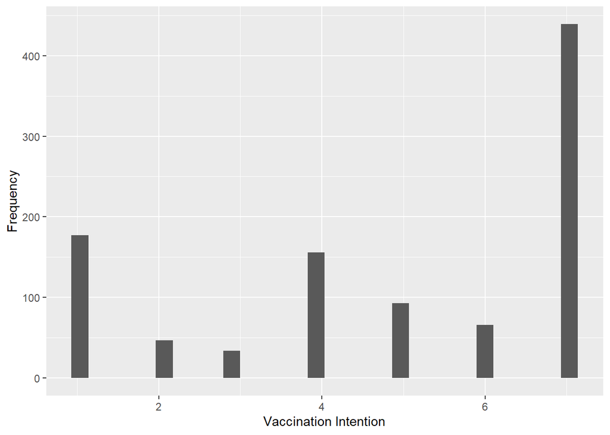

```r
    ggplot(df1, aes(vaxx, na.rm=T)) +
    geom_histogram()+
    labs(x="Vaccination Intention", y="Frequency")
```

### Fear of infection

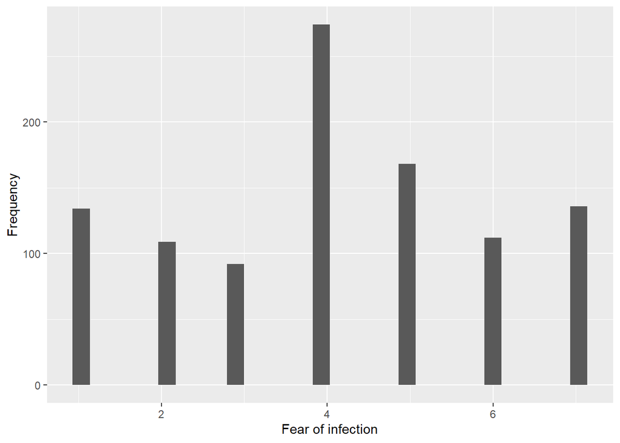

```r
    ggplot(df1, aes(fear_infect, na.rm=T)) +
    geom_histogram()+
    labs(x="Fear of infection", y="Frequency")
```

### Fear of transmission

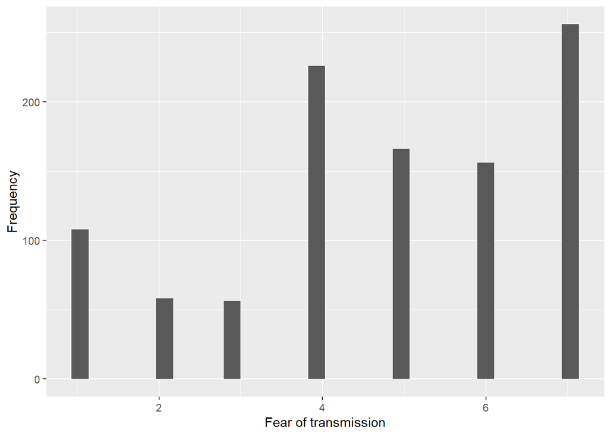

```r
    ggplot(df1, aes(fear_contr, na.rm=T)) +
    geom_histogram()+
    labs(x="Fear of transmission", y="Frequency")
```

### Health consciousness

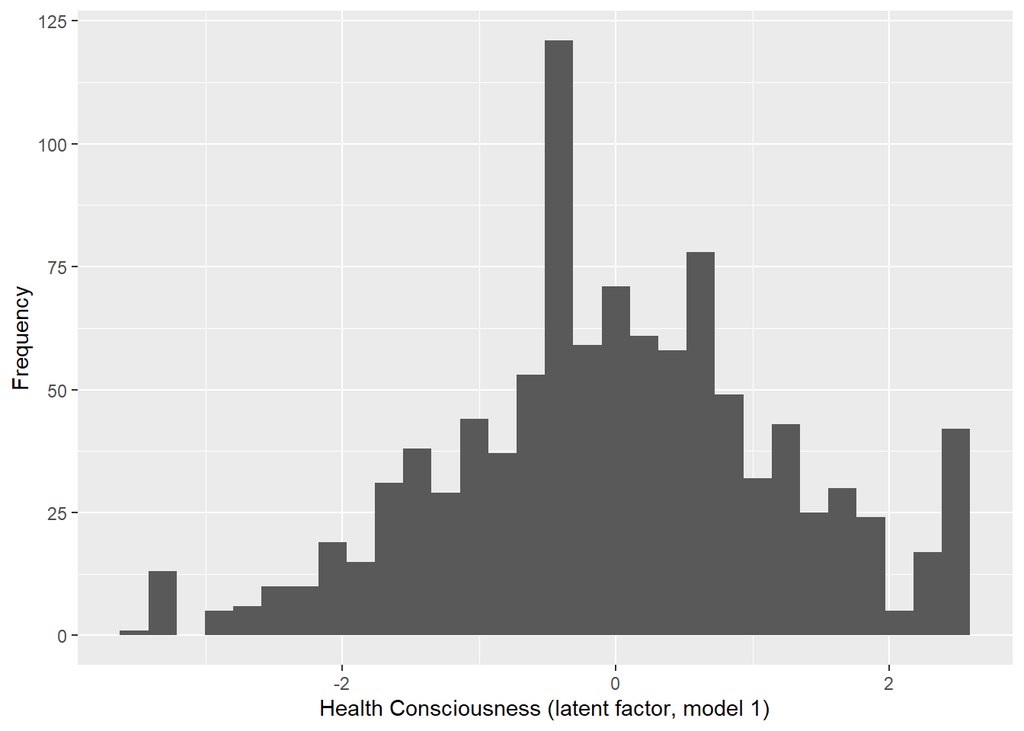

```r
    ggplot(df1_pr, aes(h_cons)) +
    geom_histogram()+
    labs(x="Health Consciousness (latent factor, model 1)", y="Frequency")
```

### Political trust

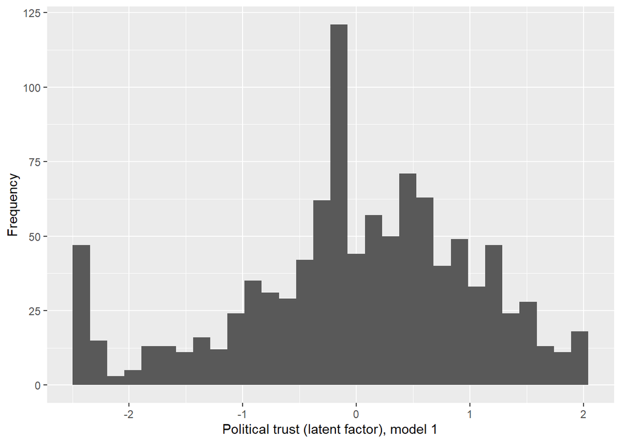

```r
    ggplot(df1_pr, aes(pol_trust)) +
    geom_histogram()+
    labs(x="Political trust (latent factor), model 1", y="Frequency")
```

### Religiosity

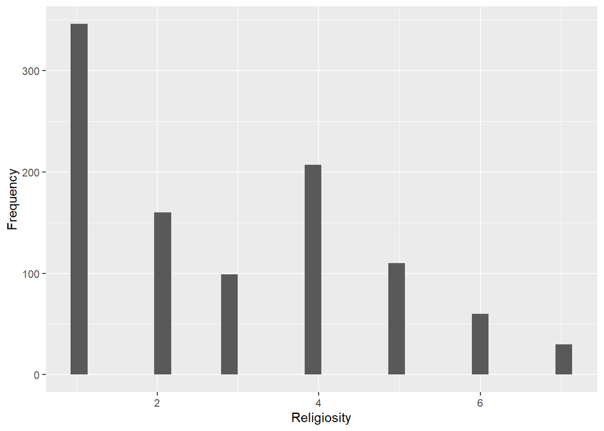

```r
    ggplot(df1, aes(rel, na.rm=T)) +
    geom_histogram()+
    labs(x="Religiosity", y="Frequency")
```

### Media country of origin

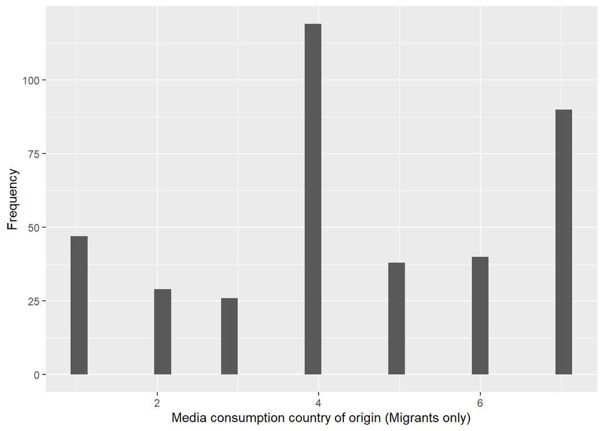

```r
    ggplot(df_m, aes(media_cor, na.rm=T)) +
    geom_histogram()+
    labs(x="Media consumption country of origin (Migrants only)", y="Frequency")
```

### Media Germany

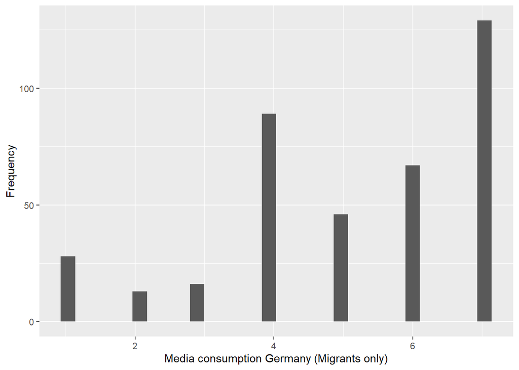

```r
    ggplot(df_m, aes(media_ger, na.rm=T)) +
    geom_histogram()+
    labs(x="Media consumption Germany (Migrants only)", y="Frequency")
```

### Years since migration

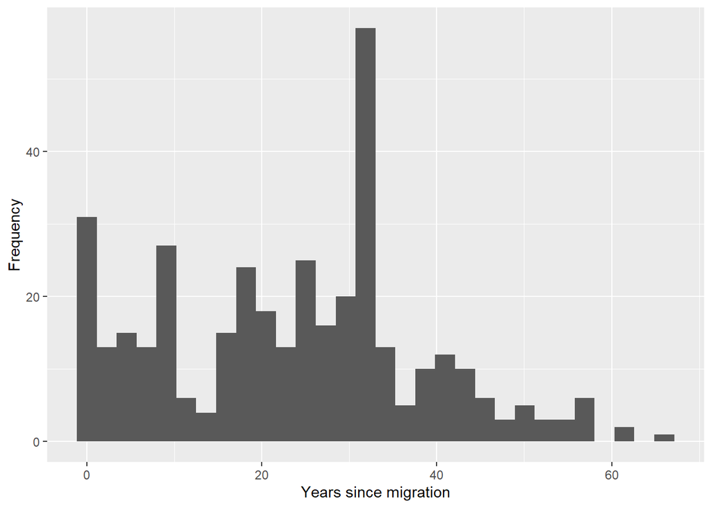

```r
    ggplot(df_m, aes(ysm*100, na.rm=T)) +
    geom_histogram()+
    labs(x="Years since migration", y="Frequency")
```

### Country of origin

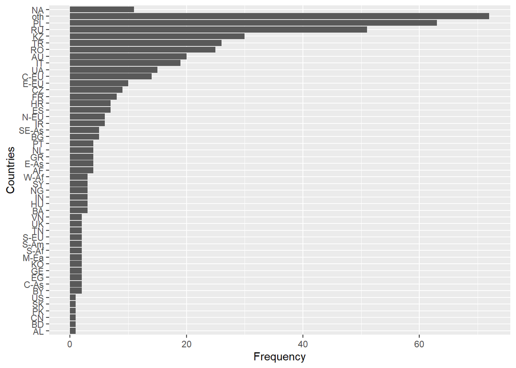

```r
df1 %>% filter(mig==1) %>%
  count(cor) %>%
  ggplot(aes(x=reorder(cor, n), y=n)) +
  geom_bar(stat="identity") +
  labs(x= "Countries", y="Frequency") +
  coord_flip()
```

### European country of origin

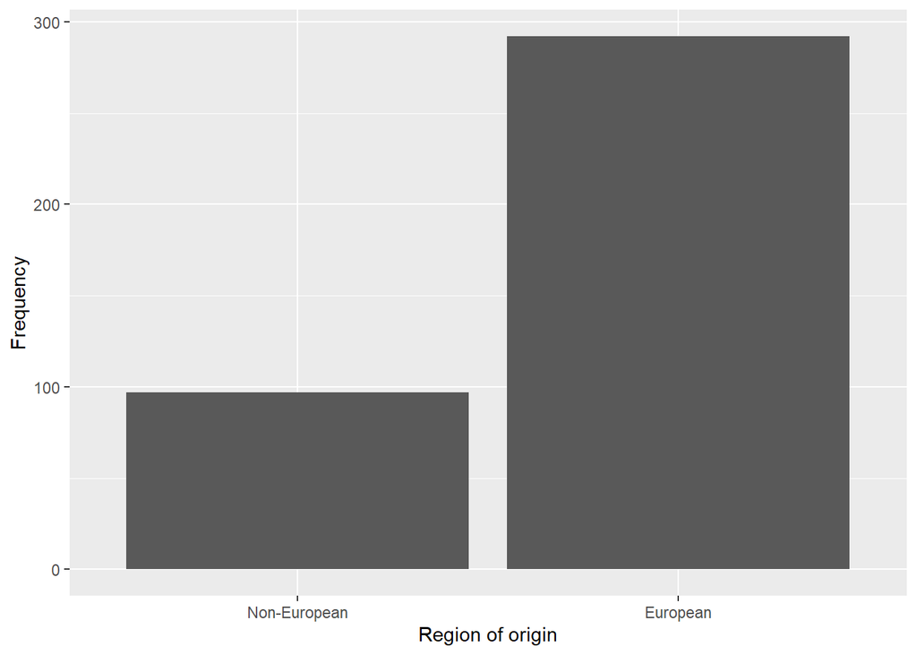

```r
  df_m %>%
    select(euro) %>%
      drop_na() %>%
  ggplot(aes(as.factor(euro))) +
    geom_bar(na.rm=T) +
    scale_x_discrete(labels=c("0" = "Non-European", "1" = "European")) +
    labs(x="Region of origin", y="Frequency")
```

### Education

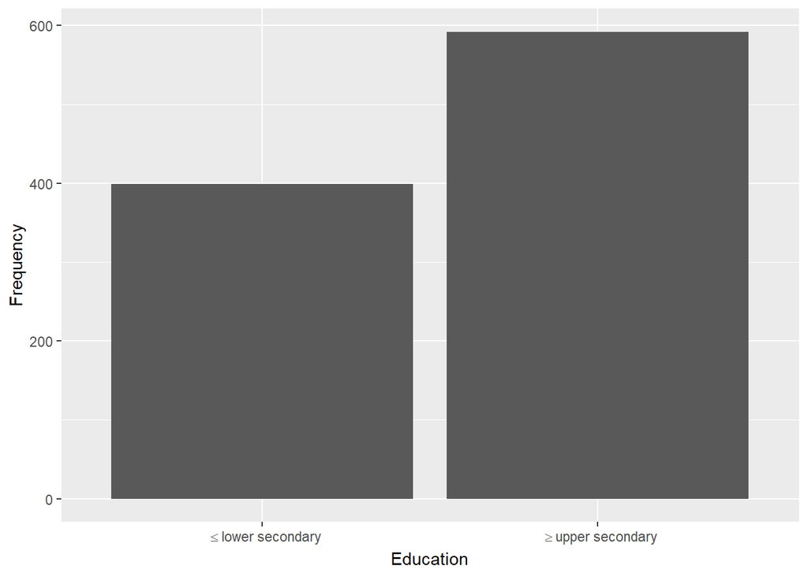

```r
  df1 %>%
    select(educ) %>%
      drop_na() %>%
  ggplot(aes(as.factor(educ))) +
    geom_bar(na.rm=T) +
    scale_x_discrete(labels=c("0" = expression(" "<="lower secondary"), "1" = expression(" ">="upper secondary"))) +
    labs(x="Education", y="Frequency")
```

### Gender

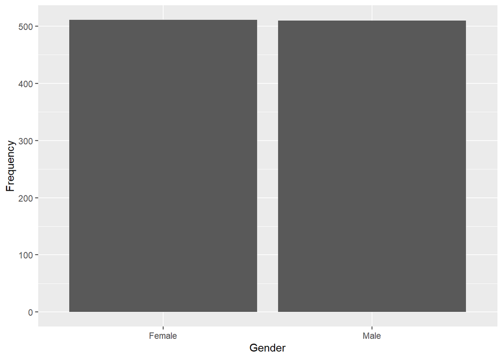

```r
  df1 %>%
    select(sex) %>%
      drop_na() %>%
  ggplot(aes(as.factor(sex))) +
    geom_bar(na.rm=T) +
    scale_x_discrete(labels=c("0" = "Female", "1" = "Male")) +
    labs(x="Gender", y="Frequency")
```

### Age

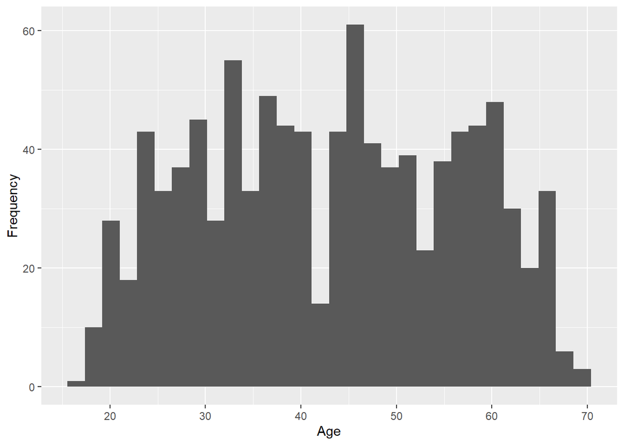

```r
    ggplot(df1, aes(age*100, na.rm=T)) +
    geom_histogram()+
    labs(x="Age", y="Frequency")
```

### Income

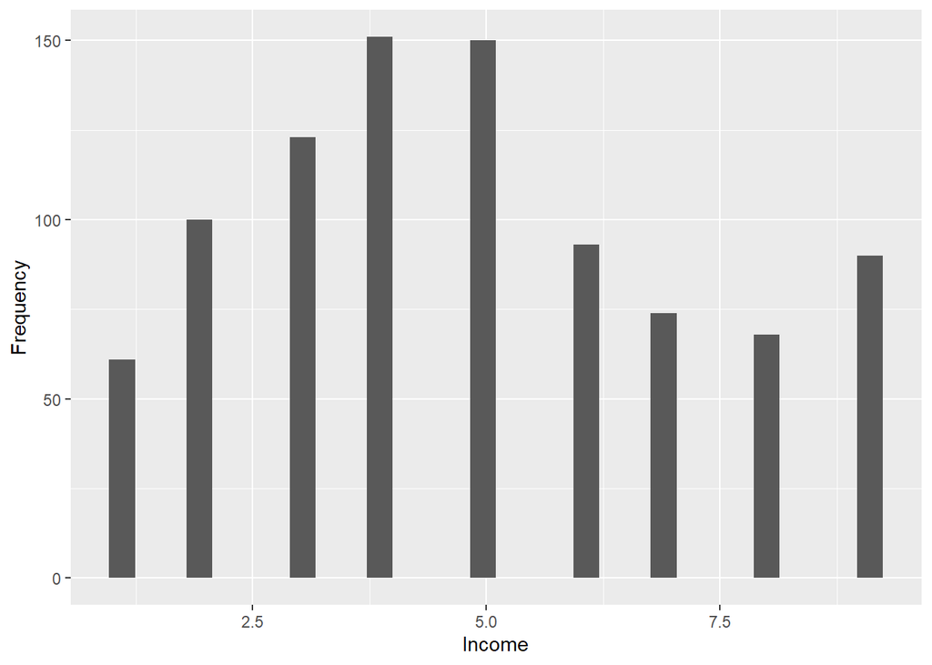

```r
    ggplot(df1, aes(inc, na.rm=T)) +
    geom_histogram()+
    labs(x="Income", y="Frequency")
```

## Empirical model 1, all respondents

Empirical model 1 of vaccination intention for all respondents according the hypothesized structure as suggested in Fig.1 in the article (without dashed lines).

*Click ‘Code’ to see syntax*

```r
model1 <- '
#measurement model
h_cons =~ h_worry  + media_di + h_imp
pol_trust =~ otrust_gov + otrust_hth + otrust_med + otrust_pol #+ otrust_parl

#Covariances
educ ~~ sex + mig + age + inc
sex ~~ mig + age + inc
mig ~~ age + inc
age ~~ inc

pol_trust ~~ h_cons + vaxx

#Error Correlations
fear_infect ~~ fear_contr
h_worry ~~ fear_infect
otrust_med ~~ otrust_pol
otrust_gov ~~  otrust_hth

#regressions
vaxx ~ a1*fear_infect + b1*fear_contr + e1*educ + f1*sex + g1*inc + h1*age
fear_infect ~ a2*pol_trust  + c2*h_cons + d2*educ + e2*sex + f2*inc + g2*age
fear_contr ~  a3*pol_trust  + c3*h_cons + d3*educ + e3*sex + f3*inc + g3*age
pol_trust ~  a4*mig + b4*rel + c4*educ + d4*sex + e4*inc + f4*age
h_cons ~ a6*mig + b6*rel + c6*educ + d6*sex + e6*inc + f6*age
rel ~ a7*mig + c7*educ + d7*sex + e7*inc + f7*age

#total effect of migration

m1:= a7*b6*c2*a1 #mig-rel-hcon-inf-vaxx
m2:= a7*b6*c3*b1 #mig-rel-hcon-contr-vaxx
m3:= a7*b4*a2*a1 #mig-rel-trust-inf-vaxx
m4:= a7*b4*a3*b1 #mig-rel-trust-contr-vaxx

totmig:= m1+m2+m3+m4

'

fit_m1 <- sem(model1, df1, meanstructure=T, missing="fiml")
```

**Click here for output**

```r
summary(fit_m1, standardized=TRUE, fit.measures = T, rsquare=T)
```

```
## lavaan 0.6-9 ended normally after 171 iterations
##
##   Estimator                                         ML
##   Optimization method                           NLMINB
##   Number of model parameters                        90
##
##   Number of observations                          1027
##   Number of missing patterns                        31
##
## Model Test User Model:
##
##   Test statistic                               284.788
##   Degrees of freedom                                62
##   P-value (Chi-square)                           0.000
##
## Model Test Baseline Model:
##
##   Test statistic                              4463.565
##   Degrees of freedom                               120
##   P-value                                        0.000
##
## User Model versus Baseline Model:
##
##   Comparative Fit Index (CFI)                    0.949
##   Tucker-Lewis Index (TLI)                       0.901
##
## Loglikelihood and Information Criteria:
##
##   Loglikelihood user model (H0)             -23714.944
##   Loglikelihood unrestricted model (H1)     -23572.549
##
##   Akaike (AIC)                               47609.887
##   Bayesian (BIC)                             48053.983
##   Sample-size adjusted Bayesian (BIC)        47768.133
##
## Root Mean Square Error of Approximation:
##
##   RMSEA                                          0.059
##   90 Percent confidence interval - lower         0.052
##   90 Percent confidence interval - upper         0.066
```

[output cut: 147 more lines]

```
##     otrust_pol        0.628
##     vaxx              0.186
##     fear_infect       0.327
##     fear_contr        0.366
##     rel               0.046
##     h_cons            0.053
##     pol_trust         0.042
##
## Defined Parameters:
##                    Estimate  Std.Err  z-value  P(>|z|)   Std.lv  Std.all
##     m1                0.010    0.004    2.471    0.013    0.010    0.002
##     m2                0.009    0.004    2.421    0.015    0.009    0.002
##     m3                0.005    0.002    2.555    0.011    0.005    0.001
##     m4                0.004    0.002    2.476    0.013    0.004    0.001
##     totmig            0.027    0.008    3.436    0.001    0.027    0.006
```

**Click here for mod.indices**

```r
modindices(fit_m1,minimum.value = 3.9, sort.=T)
```

```
##            lhs op         rhs     mi     epc sepc.lv sepc.all sepc.nox
## 238       educ  ~        vaxx 44.286   0.813   0.813    3.811    3.811
## 278        mig  ~        vaxx 43.876  -0.048  -0.048   -0.219   -0.219
## 107    h_worry ~~    media_di 40.445  -0.689  -0.689   -0.476   -0.476
## 241       educ  ~   pol_trust 40.341   4.338   4.821    9.835    9.835
## 251        sex  ~   pol_trust 40.306  -5.450  -6.057  -12.111  -12.111
## 192       vaxx ~~         sex 40.288  -4.786  -4.786   -4.615   -4.615
## 191       vaxx ~~        educ 40.281   3.808   3.808    3.746    3.746
## 194       vaxx ~~         age 40.269  -0.706  -0.706   -2.545   -2.545
## 195       vaxx ~~         mig 40.264  -0.207  -0.207   -0.200   -0.200
## 216       vaxx  ~         mig 40.263  -0.844  -0.844   -0.183   -0.183
## 281        mig  ~   pol_trust 40.263  -0.236  -0.262   -0.525   -0.525
## 271        age  ~   pol_trust 40.233  -0.803  -0.892   -6.675   -6.675
## 193       vaxx ~~         inc 40.203 172.548 172.548   35.737   35.737
## 261        inc  ~   pol_trust 40.134 196.287 218.135   93.686   93.686
```

[output cut: 42 more lines]

## Empirical model 1+, all respondents with additional paths

Empirical model 1+ of vaccination intention for all respondents as in Fig.1 in the article (with dashed lines).

*Click ‘Code’ to see syntax*

```r
model2 <- '
#measurement model
h_cons =~ h_worry  + media_di + h_imp
pol_trust =~ otrust_gov + otrust_hth + otrust_med + otrust_pol #+ otrust_parl

#Covariances
educ ~~ sex + mig + age + inc
sex ~~ mig + age + inc
mig ~~ age + inc
age ~~ inc

h_cons ~~ pol_trust + vaxx

#Error Correlations
fear_infect ~~ fear_contr
h_worry ~~ fear_infect

otrust_med ~~ otrust_pol
otrust_gov ~~  otrust_hth

#regressions
vaxx ~ a1*fear_infect + b1*fear_contr  + i1*mig + x1*rel + e1*educ + f1*sex + g1*inc + h1*age + k1*pol_trust
fear_infect ~ a2*pol_trust  + c2*h_cons + d2*educ + e2*sex + f2*inc + g2*age
fear_contr ~  a3*pol_trust  + c3*h_cons + d3*educ + e3*sex + f3*inc + g3*age + x3*rel
pol_trust ~  a4*mig + b4*rel + c4*educ + d4*sex + e4*inc + f4*age
h_cons ~ a6*mig + b6*rel + c6*educ + d6*sex + e6*inc + f6*age
rel ~ a7*mig + c7*educ + d7*sex + e7*inc + f7*age

#total effect of migration

m1:= a7*b6*c2*a1 #mig-rel-hcon-inf-vaxx
m2:= a7*b6*c3*b1 #mig-rel-hcon-contr-vaxx
m3:= a7*b4*a2*a1 #mig-rel-trust-inf-vaxx
m4:= a7*b4*a3*b1 #mig-rel-trust-contr-vaxx

m5:= a7*b4*k1    #mig-rel-trust-vaxx
m6:= a7*x3*b1    #mig-rel-contr-vaxx
m7:= a7*x1    #mig-rel-vaxx

totmig:= m1+m2+m3+m4+m5+m6+m7+i1

'

fit_m2 <- sem(model2, df1, meanstructure=T, missing="fiml")
```

**Click here for output**

```r
summary(fit_m2, standardized=TRUE, fit.measures = T, rsquare=T)
```

```
## lavaan 0.6-9 ended normally after 173 iterations
##
##   Estimator                                         ML
##   Optimization method                           NLMINB
##   Number of model parameters                        94
##
##   Number of observations                          1027
##   Number of missing patterns                        31
##
## Model Test User Model:
##
##   Test statistic                               232.772
##   Degrees of freedom                                58
##   P-value (Chi-square)                           0.000
##
## Model Test Baseline Model:
##
##   Test statistic                              4463.565
##   Degrees of freedom                               120
##   P-value                                        0.000
##
## User Model versus Baseline Model:
##
##   Comparative Fit Index (CFI)                    0.960
##   Tucker-Lewis Index (TLI)                       0.917
##
## Loglikelihood and Information Criteria:
##
##   Loglikelihood user model (H0)             -23688.935
##   Loglikelihood unrestricted model (H1)     -23572.549
##
##   Akaike (AIC)                               47565.871
##   Bayesian (BIC)                             48029.704
##   Sample-size adjusted Bayesian (BIC)        47731.150
##
## Root Mean Square Error of Approximation:
##
##   RMSEA                                          0.054
##   90 Percent confidence interval - lower         0.047
##   90 Percent confidence interval - upper         0.062
```

[output cut: 156 more lines]

```
##     fear_contr        0.370
##     rel               0.046
##     h_cons            0.057
##     pol_trust         0.033
##
## Defined Parameters:
##                    Estimate  Std.Err  z-value  P(>|z|)   Std.lv  Std.all
##     m1                0.009    0.004    2.475    0.013    0.009    0.002
##     m2                0.008    0.004    2.201    0.028    0.008    0.002
##     m3                0.004    0.002    2.268    0.023    0.004    0.001
##     m4                0.003    0.001    2.046    0.041    0.003    0.001
##     m5                0.039    0.013    2.855    0.004    0.039    0.008
##     m6               -0.005    0.003   -1.645    0.100   -0.005   -0.001
##     m7               -0.076    0.027   -2.836    0.005   -0.076   -0.016
##     totmig           -0.780    0.123   -6.368    0.000   -0.780   -0.170
```

**Click here for mod.indices**

```r
modindices(fit_m2,minimum.value = 3.9, sort.=T)
```

```
##            lhs op         rhs     mi    epc sepc.lv sepc.all sepc.nox
## 114    h_worry ~~    media_di 38.522 -0.665  -0.665   -0.459   -0.459
## 226 fear_contr  ~ fear_infect 26.031  1.379   1.379    1.330    1.330
## 121    h_worry ~~  fear_contr 26.031  0.474   0.474    0.258    0.258
## 134   media_di ~~ fear_infect 24.750  0.417   0.417    0.227    0.227
## 147      h_imp ~~ fear_infect 23.540 -0.298  -0.298   -0.144   -0.144
## 135   media_di ~~  fear_contr 16.585 -0.334  -0.334   -0.182   -0.182
## 141   media_di ~~         age 14.080 -0.024  -0.024   -0.149   -0.149
## 115    h_worry ~~       h_imp 13.824  0.282   0.282    0.172    0.172
## 112  pol_trust =~    media_di 13.681  0.204   0.226    0.134    0.134
## 129   media_di ~~  otrust_gov 11.231  0.172   0.172    0.125    0.125
## 176 otrust_hth ~~         age 10.352 -0.015  -0.015   -0.116   -0.116
## 181 otrust_med ~~         mig  7.852 -0.053  -0.053   -0.087   -0.087
## 137   media_di ~~         mig  7.683  0.067   0.067    0.111    0.111
## 154      h_imp ~~         age  7.247  0.016   0.016    0.088    0.088
```

[output cut: 18 more lines]

## Empirical model 2, migrants only

Empirical model 2 of vaccination intention for migrants only, according the hypothesized structure as suggested in Fig.1 in the article (without dashed lines).

*Click ‘Code’ to see syntax*

```r
model_m1 <- '
  #measurement model
  h_cons =~ h_worry  + media_di + h_imp
  pol_trust =~ otrust_gov + otrust_hth + otrust_med +  otrust_pol #+ otrust_parl

  #Covariances
  educ ~~ age + sex + inc + ysm  + euro
  age ~~ sex + inc + ysm  + euro
  sex ~~ inc + ysm  + euro
  inc ~~ ysm  + euro
  ysm ~~ euro


pol_trust ~~ h_cons + vaxx

#Error Correlations
fear_infect ~~ fear_contr
h_worry ~~ fear_infect
media_cor ~~ media_ger

otrust_med ~~ otrust_pol
otrust_gov ~~  otrust_hth

#regressions
vaxx ~ a1*fear_infect + b1*fear_contr  + e1*educ + f1*sex + g1*inc + h1*age
fear_infect ~ a2*pol_trust  + d2*h_cons +  j2*educ + k2*sex + l2*inc + m2*age
fear_contr ~  a3*pol_trust + d3*h_cons + j3*educ + k3*sex + l3*inc + m3*age
pol_trust ~  a4*media_cor + b4*media_ger  + x4*ysm + h4*euro + c4*rel + d4*educ + e4*sex + f4*inc + g4*age
h_cons ~ a6*media_cor + b6*media_ger + x6*ysm  + d6*euro + e6*rel + f6*educ + g6*sex + h6*inc + i6*age
media_cor ~ a7*ysm + b7*euro + c7*educ + d7*sex + e7*inc + f7*age
media_ger ~ a8*ysm + b8*euro + c8*educ + d8*sex + e8*inc + f8*age
rel ~ a9*ysm + b9*euro + c9*educ + d9*sex + e9*inc + f9*age
'

fit_m1 <- sem(model_m1, df_m, meanstructure=T, missing="fiml")
```

**Click here for output**

```r
summary(fit_m1, standardized=TRUE, fit.measures = T, rsquare=T)
```

```
## lavaan 0.6-9 ended normally after 245 iterations
##
##   Estimator                                         ML
##   Optimization method                           NLMINB
##   Number of model parameters                       121
##
##                                                   Used       Total
##   Number of observations                           389         423
##   Number of missing patterns                        22
##
## Model Test User Model:
##
##   Test statistic                               175.429
##   Degrees of freedom                                88
##   P-value (Chi-square)                           0.000
##
## Model Test Baseline Model:
##
##   Test statistic                              1964.900
##   Degrees of freedom                               171
##   P-value                                        0.000
##
## User Model versus Baseline Model:
##
##   Comparative Fit Index (CFI)                    0.951
##   Tucker-Lewis Index (TLI)                       0.905
##
## Loglikelihood and Information Criteria:
##
##   Loglikelihood user model (H0)             -10276.206
##   Loglikelihood unrestricted model (H1)     -10188.491
##
##   Akaike (AIC)                               20794.411
##   Bayesian (BIC)                             21274.005
##   Sample-size adjusted Bayesian (BIC)        20890.081
##
## Root Mean Square Error of Approximation:
##
##   RMSEA                                          0.051
##   90 Percent confidence interval - lower         0.040
```

[output cut: 179 more lines]

```
##     h_worry           0.494
##     media_di          0.420
##     h_imp             0.257
##     otrust_gov        0.367
##     otrust_hth        0.646
##     otrust_med        0.466
##     otrust_pol        0.718
##     vaxx              0.227
##     fear_infect       0.210
##     fear_contr        0.300
##     media_cor         0.041
##     media_ger         0.060
##     rel               0.048
##     h_cons            0.100
##     pol_trust         0.163
```

**Click here for mod.indices**

```r
modindices(fit_m1,minimum.value = 3.9, sort.=T)
```

```
##             lhs op         rhs     mi    epc sepc.lv sepc.all sepc.nox
## 156    media_di ~~ fear_infect 26.381  0.717   0.717    0.342    0.342
## 172       h_imp ~~ fear_infect 19.100 -0.492  -0.492   -0.207   -0.207
## 334        educ  ~        vaxx  9.809  0.333   0.333    1.677    1.677
## 363         inc  ~   pol_trust  9.321 56.492  55.599   23.752   23.752
## 242        vaxx ~~         inc  9.316 30.393  30.393    6.243    6.243
## 347         sex  ~        vaxx  8.952 -0.178  -0.178   -0.843   -0.843
## 222  otrust_med ~~        euro  7.941  0.074   0.074    0.146    0.146
## 241        vaxx ~~         sex  7.819 -0.772  -0.772   -0.743   -0.743
## 350         sex  ~   pol_trust  7.817 -1.434  -1.411   -2.826   -2.826
## 323   media_ger  ~   pol_trust  7.747  0.921   0.907    0.497    0.497
## 160    media_di ~~         rel  7.559  0.382   0.382    0.169    0.169
## 157    media_di ~~  fear_contr  7.344 -0.352  -0.352   -0.177   -0.177
## 386         ysm  ~        vaxx  7.114  0.008   0.008    0.125    0.125
## 331         rel  ~      h_cons  6.787  0.863   0.977    0.523    0.523
```

[output cut: 39 more lines]

## Empirical model 2+, migrants only with additional paths

Empirical model 2+ of vaccination intention for migrants only as in Fig.1 in the article (with dashed lines).

*Click ‘Code’ to see syntax*

```r
model_m2 <- '
  #measurement model
  h_cons =~ h_worry  + media_di + h_imp
  pol_trust =~ otrust_gov + otrust_hth + otrust_med +  otrust_pol #+ otrust_parl

  #Covariances
  educ ~~ age + sex + inc + ysm  + euro
  age ~~ sex + inc + ysm  + euro
  sex ~~ inc + ysm  + euro
  inc ~~ ysm  + euro
  ysm ~~ euro

pol_trust ~~ h_cons + vaxx

#Error Correlations
fear_infect ~~ fear_contr
h_worry ~~ fear_infect
media_cor ~~ media_ger

otrust_med ~~ otrust_pol
otrust_gov ~~  otrust_hth


#regressions

vaxx ~ a1*fear_infect + b1*fear_contr  + e1*educ + f1*sex + g1*inc + h1*age + x1*euro + y1*rel + q1*media_ger
fear_infect ~ a2*pol_trust  + d2*h_cons +  j2*educ + k2*sex + l2*inc + m2*age + n2*euro
fear_contr ~  a3*pol_trust + d3*h_cons + j3*educ + k3*sex + l3*inc + m3*age
pol_trust ~  a4*media_cor + b4*media_ger  + x4*ysm + h4*euro + c4*rel + d4*educ + e4*sex + f4*inc + g4*age
h_cons ~ a6*media_cor + b6*media_ger + x6*ysm  + d6*euro + e6*rel + f6*educ + g6*sex + h6*inc + i6*age
media_cor ~ a7*ysm + b7*euro + c7*educ + d7*sex + e7*inc + f7*age
media_ger ~ a8*ysm + b8*euro + c8*educ + d8*sex + e8*inc + f8*age
rel ~ a9*ysm + b9*euro + c9*educ + d9*sex + e9*inc + f9*age
'


fit_m2 <- sem(model_m2, df_m, meanstructure=T, missing="fiml")
```

**Click here for output**

```r
summary(fit_m2, standardized=TRUE, fit.measures = T, rsquare=T)
```

```
## lavaan 0.6-9 ended normally after 242 iterations
##
##   Estimator                                         ML
##   Optimization method                           NLMINB
##   Number of model parameters                       125
##
##                                                   Used       Total
##   Number of observations                           389         423
##   Number of missing patterns                        22
##
## Model Test User Model:
##
##   Test statistic                               154.131
##   Degrees of freedom                                84
##   P-value (Chi-square)                           0.000
##
## Model Test Baseline Model:
##
##   Test statistic                              1964.900
##   Degrees of freedom                               171
##   P-value                                        0.000
##
## User Model versus Baseline Model:
##
##   Comparative Fit Index (CFI)                    0.961
##   Tucker-Lewis Index (TLI)                       0.920
##
## Loglikelihood and Information Criteria:
##
##   Loglikelihood user model (H0)             -10265.557
##   Loglikelihood unrestricted model (H1)     -10188.491
##
##   Akaike (AIC)                               20781.113
##   Bayesian (BIC)                             21276.561
##   Sample-size adjusted Bayesian (BIC)        20879.945
##
## Root Mean Square Error of Approximation:
##
##   RMSEA                                          0.046
##   90 Percent confidence interval - lower         0.035
```

[output cut: 183 more lines]

```
##     h_worry           0.493
##     media_di          0.423
##     h_imp             0.257
##     otrust_gov        0.371
##     otrust_hth        0.650
##     otrust_med        0.475
##     otrust_pol        0.725
##     vaxx              0.260
##     fear_infect       0.218
##     fear_contr        0.300
##     media_cor         0.041
##     media_ger         0.060
##     rel               0.048
##     h_cons            0.099
##     pol_trust         0.186
```

**Click here for mod.indices**

```r
modindices(fit_m2,minimum.value = 3.9, sort.=T)
```

```
##            lhs op         rhs     mi    epc sepc.lv sepc.all sepc.nox
## 160   media_di ~~ fear_infect 25.619  0.705   0.705    0.339    0.339
## 176      h_imp ~~ fear_infect 20.640 -0.507  -0.507   -0.215   -0.215
## 225 otrust_med ~~        euro  7.965  0.075   0.075    0.147    0.147
## 164   media_di ~~         rel  7.509  0.382   0.382    0.169    0.169
## 161   media_di ~~  fear_contr  7.079 -0.345  -0.345   -0.174   -0.174
## 334       educ  ~        vaxx  6.863  0.291   0.291    1.466    1.466
## 330        rel  ~   pol_trust  6.764  0.655   0.651    0.348    0.348
## 331        rel  ~      h_cons  6.722  0.866   0.981    0.525    0.525
## 137    h_worry ~~    media_di  6.621 -0.455  -0.455   -0.319   -0.319
## 214 otrust_hth ~~         ysm  6.560 -0.019  -0.019   -0.125   -0.125
## 131     h_cons =~  otrust_hth  6.446 -0.188  -0.212   -0.125   -0.125
## 189 otrust_gov ~~        vaxx  5.613  0.300   0.300    0.114    0.114
## 399        ysm  ~        vaxx  5.442  0.007   0.007    0.113    0.113
## 373        age  ~        vaxx  5.439 -0.014  -0.014   -0.261   -0.261
```

[output cut: 16 more lines]